# Linear Regression Assumptions

Linear Regression Assumptions The multiple linear regression model uses all of the assumptions of the classical simple (a.k.a. two-variable) linear regression model, but also assumes that the independent variables are not collinear. Assumption of a multiple linear regression model are as follows:

- A linear relationship exists between the dependent and independent variables.
- The independent variables are not correlated with the error (disturbance) term: corr(X1i, εi) = corr(X1i, εi) = 0. If X1i and X2i are nonstochastic (i.e., X1i and X2i are fixed numbers) then the condition is satisfied.
- The conditional expectation of the error given Xi is zero: E(εi|X1i) = E(εi|X2i) = 0.
- The variance of the error terms is constant for all observations (homoskedasticity).
- The error term of one observation is not correlated with that of another observation.
- The model is correctly specified in that it includes only the appropriate independent variables and does not omit variables.
- The independent variables are not collinear (i.e., the independent variables are not random, and there is no exact linear relation between any two or more independent variables). In the simple regression case, this means there is no expression of one independent variable in terms of another: X2i = A0 + A1 × X1i. This expression does not have an error or residual term, which means that it represents a perfectly collinear relationship.
- Only the meaningful variables should be included.
- The independent variables should be independent of each other. That is, the model should have little or no multicollinearity.
- The independent variables are linearly related to the dependent variable.
- Linear regression requires quite large sample sizes.

Keeping the above assumptions in mind, let’s look at our dataset.

# Data

The dataset comes from Intrinsic Value, and it is related to valuation engagements of Israeli privately-held companies. The regression goal is to predict the enterprise value of a privately-held company (variable y). The dataset can be downloaded from here.

```python
import pandas as pd
import numpy as np
import matplotlib.pyplot as plt
import seaborn as sns
from sklearn import preprocessing
import matplotlib.pyplot as plt
from sklearn.linear_model import LogisticRegression
from sklearn.model_selection import train_test_split
```

The dataset provides intrinsic value’s valuations information. It includes 1,061 records and 8 fields.

```python
data = pd.read_csv('enterprise.csv')
data = data.dropna()
print(data.shape)
print(list(data.columns))
```

```
(1061, 8)
['valuationdate', 'revenues', 'ebit', 'depreciation', 'capex', 'ncwc', 'bv', 'y']
```

```python
data.head()
```

|  | valuationdate | revenues | ebit | depreciation | capex | ncwc | bv | y |
| --- | --- | --- | --- | --- | --- | --- | --- | --- |
| 0 | 30/06/2011 | 86470.7000 | 10387.500000 | 6429.000 | 3512.000 | 16848.90000 | 47945.100 | 91760.80000 |
| 1 | 31/12/2010 | 84754.2000 | 14031.180800 | 8658.600 | 17172.500 | 12095.10000 | 66804.400 | 184461.70000 |
| 2 | 30/09/2016 | 15653.4800 | 221.347452 | 647.239 | 749.478 | 1468.42800 | 10128.726 | 23323.68520 |
| 3 | 30/09/2018 | 62001.3297 | 7551.761957 | 1808.830 | 2702.850 | 11873.25464 | 27144.930 | 130202.79240 |
| 4 | 30/09/2014 | 1242.8300 | 497.141501 | 232.027 | 1552.908 | 149.97100 | 1463.052 | 11472.12267 |

### Input variables

- valuationdate: the specific point in time as of which the valuator’s opinion of value applies (categorical).
- revenues: the LTM (last twelve months) revenues of the company, as reported in the company’s statement of income, as of the valuation date (numeric).
- ebit : the LTM (last twelve months) operating income (revenues minus (cost of goods sold minus selling, general & administrative expenses minus research and development expenses) of the company, as reported in the company’s statement of income, as of the valuation date (numeric).
- depreciation: the LTM (last twelve months) depreciation and amortization of the company, as reported in the company’s statement of cash flow, as of the valuation date (numeric).
- capex: the LTM (last twelve months) capital expenditures of the company, as reported in the company’s statement of cash flow, as of the valuation date (numeric).
- ncwc: the non-cash working capital (current assets excluding cash and marketable securities minus current liabilities excluding interest bearing debt) of the company, as reported on the company’s balance sheet, as of the valuation date (numeric).
- bv: the book value of common equity of the company, as reported on the company’s balance sheet, as of the valuation date (numeric).

### Predict variable (desired target):

- y — the enterprise value of a privately-held, based on a DCF valuation performed by intrinsic value, as of the valuation date (numeric).

# Data exploration

```python
data.info()
```

```
<class 'pandas.core.frame.DataFrame'>
Int64Index: 1061 entries, 0 to 1060
Data columns (total 8 columns):
 #   Column         Non-Null Count  Dtype
---  ------         --------------  -----
 0   valuationdate  1061 non-null   object
 1   revenues       1061 non-null   float64
 2   ebit           1061 non-null   float64
 3   depreciation   1061 non-null   float64
 4   capex          1061 non-null   float64
 5   ncwc           1061 non-null   float64
 6   bv             1061 non-null   float64
 7   y              1061 non-null   float64
dtypes: float64(7), object(1)
memory usage: 74.6+ KB
```

```python
data.describe()
```

|  | revenues | ebit | depreciation | capex | ncwc | bv | y |
| --- | --- | --- | --- | --- | --- | --- | --- |
| count | 1.061000e+03 | 1061.000000 | 1061.000000 | 1061.000000 | 1061.000000 | 1.061000e+03 | 1.061000e+03 |
| mean | 1.632727e+05 | 24076.406810 | 8002.050367 | 10961.602205 | 22324.130946 | 8.057162e+04 | 3.292238e+05 |
| std | 2.213828e+05 | 31871.076559 | 13898.135849 | 20250.735197 | 54636.421540 | 1.043500e+05 | 4.056701e+05 |
| min | 8.560000e+01 | -29982.979880 | -5.690000 | -694.661000 | -118819.899000 | -1.503965e+04 | 3.692000e+02 |
| 25% | 4.265958e+04 | 4522.900000 | 999.340000 | 1666.600000 | 3115.247000 | 1.689500e+04 | 6.981010e+04 |
| 50% | 1.082011e+05 | 12224.611950 | 3446.250000 | 4949.447000 | 10736.200000 | 4.172290e+04 | 1.850416e+05 |
| 75% | 1.862485e+05 | 32228.941870 | 8361.220000 | 11201.479000 | 23454.185000 | 1.147563e+05 | 4.258273e+05 |
| max | 2.586712e+06 | 289541.300000 | 128993.500000 | 205525.700000 | 623588.700000 | 1.009026e+06 | 4.175892e+06 |

```python
# find out correlation between params
data.corr()
```

|  | revenues | ebit | depreciation | capex | ncwc | bv | y |
| --- | --- | --- | --- | --- | --- | --- | --- |
| revenues | 1.000000 | 0.682297 | 0.563150 | 0.609471 | 0.275313 | 0.693262 | 0.530673 |
| ebit | 0.682297 | 1.000000 | 0.743015 | 0.766196 | 0.335241 | 0.842905 | 0.716322 |
| depreciation | 0.563150 | 0.743015 | 1.000000 | 0.848817 | 0.218191 | 0.766616 | 0.563432 |
| capex | 0.609471 | 0.766196 | 0.848817 | 1.000000 | 0.164111 | 0.731001 | 0.486895 |
| ncwc | 0.275313 | 0.335241 | 0.218191 | 0.164111 | 1.000000 | 0.389992 | 0.331766 |
| bv | 0.693262 | 0.842905 | 0.766616 | 0.731001 | 0.389992 | 1.000000 | 0.762673 |
| y | 0.530673 | 0.716322 | 0.563432 | 0.486895 | 0.331766 | 0.762673 | 1.000000 |

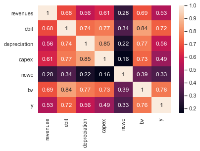

```python
sns.heatmap(data.corr(),annot=True)
```

```python
corr_matrix = data.corr()
corr_matrix["y"].sort_values(ascending=False)
```

```
y               1.000000
bv              0.762673
ebit            0.716322
depreciation    0.563432
revenues        0.530673
capex           0.486895
ncwc            0.331766
Name: y, dtype: float64
```

# Visualizations

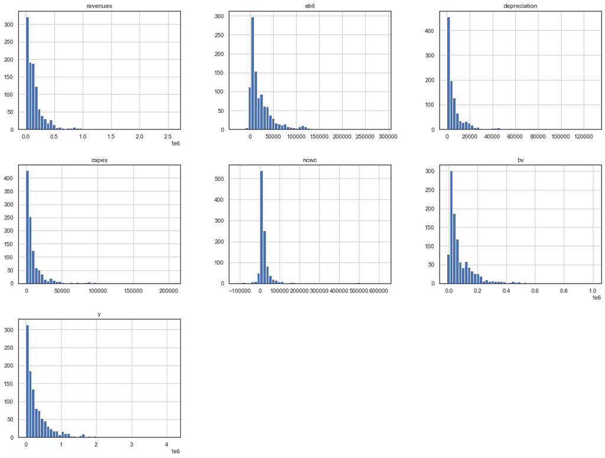

```python
%matplotlib inline
import matplotlib.pyplot as plt
data.hist(bins=50, figsize=(20,15))
plt.savefig("attribute_histogram_plots")
plt.show()
```

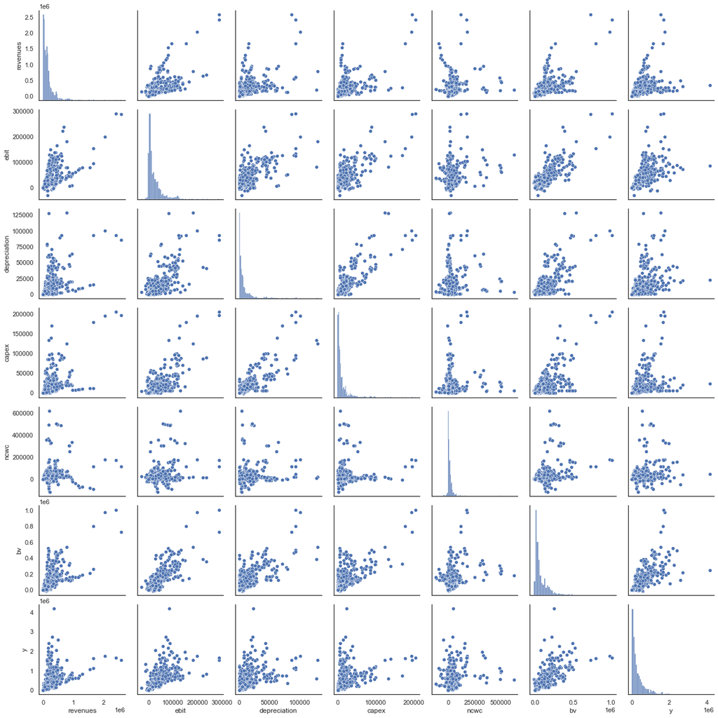

```python
sns.pairplot(data, palette='orange')
```

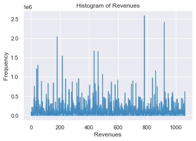

```python
sns.set(style="dark")
sns.set(style="darkgrid", color_codes=True)
data.revenues.plot.area(color='tab:blue',stacked=None)
plt.title('Histogram of Revenues')
plt.xlabel('Revenues')
plt.ylabel('Frequency')
```

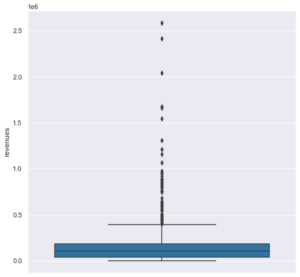

```python
a4_dims = (8, 8)
fig, ax = plt.subplots(figsize=a4_dims)
sns.set(style="dark")
sns.set(style="darkgrid", color_codes=True)
sns.boxplot(y=data.revenues, color='tab:blue')
```

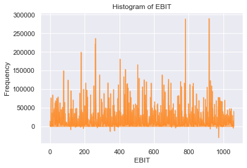

```python
data.ebit.plot.area(color='tab:orange',stacked=None)
plt.title('Histogram of EBIT')
plt.xlabel('EBIT')
plt.ylabel('Frequency')
```

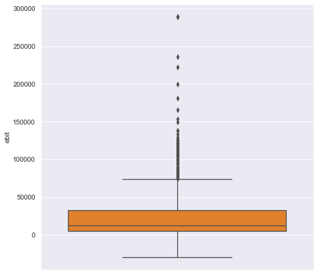

```python
a4_dims = (8, 8)
fig, ax = plt.subplots(figsize=a4_dims)
sns.set(style="dark")
sns.set(style="darkgrid", color_codes=True)
sns.boxplot(y=data.ebit, color='tab:orange')
```

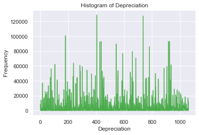

```python
data.depreciation.plot.area(color='tab:green',stacked=None)
plt.title('Histogram of Depreciation')
plt.xlabel('Depreciation')
plt.ylabel('Frequency')
```

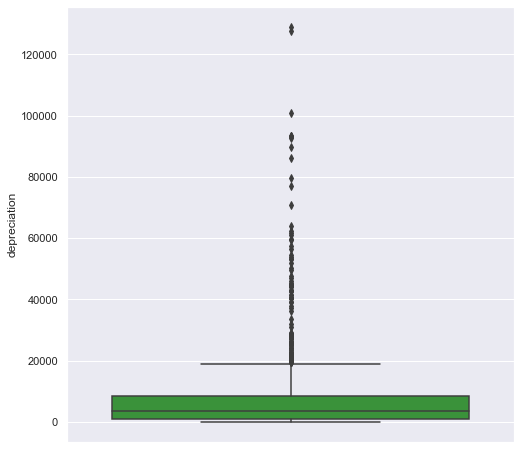

```python
a4_dims = (8, 8)
fig, ax = plt.subplots(figsize=a4_dims)
sns.set(style="dark")
sns.set(style="darkgrid", color_codes=True)
sns.boxplot(y=data.depreciation, color="tab:green")
```

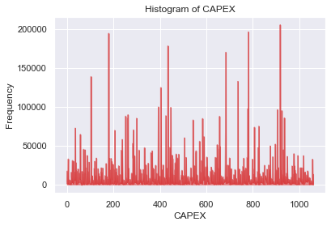

```python
data.capex.plot.area(color='tab:red',stacked=None)
plt.title('Histogram of CAPEX')
plt.xlabel('CAPEX')
plt.ylabel('Frequency')
```

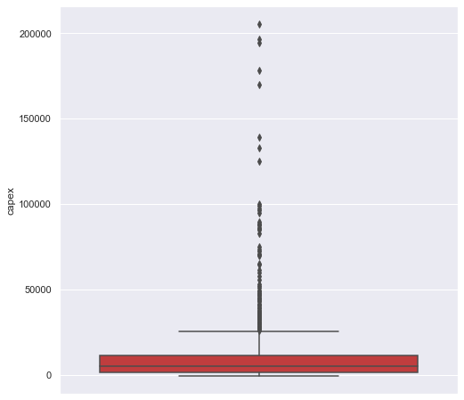

```python
a4_dims = (8, 8)
fig, ax = plt.subplots(figsize=a4_dims)
sns.set(style="dark")
sns.set(style="darkgrid", color_codes=True)
sns.boxplot(y=data.capex, color="tab:red")
```

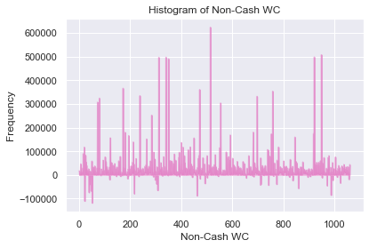

```python
data.ncwc.plot.area(color='tab:pink',stacked=None)
plt.title('Histogram of Non-Cash WC')
plt.xlabel('Non-Cash WC')
plt.ylabel('Frequency')
```

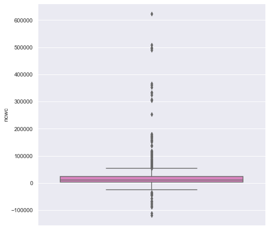

```python
a4_dims = (8, 8)
fig, ax = plt.subplots(figsize=a4_dims)
sns.set(style="dark")
sns.set(style="darkgrid", color_codes=True)
sns.boxplot(y=data.ncwc, color="tab:pink")
```

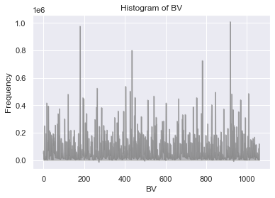

```python
data.bv.plot.area(color='tab:gray',stacked=None)
plt.title('Histogram of BV')
plt.xlabel('BV')
plt.ylabel('Frequency')
```

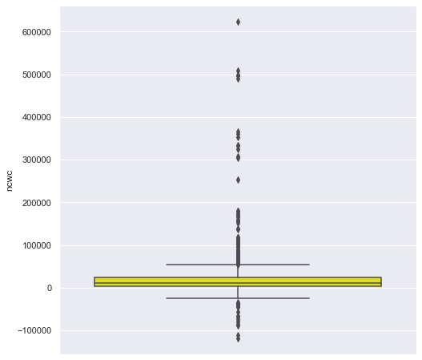

```python
a4_dims = (8, 8)
fig, ax = plt.subplots(figsize=a4_dims)
sns.set(style="dark")
sns.set(style="darkgrid", color_codes=True)
sns.boxplot(y=data.ncwc, color='yellow')
```

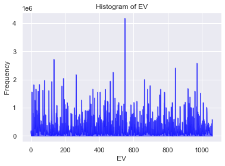

```python
data.y.plot.area(color='blue',stacked=None)
plt.title('Histogram of EV')
plt.xlabel('EV')
plt.ylabel('Frequency')
```

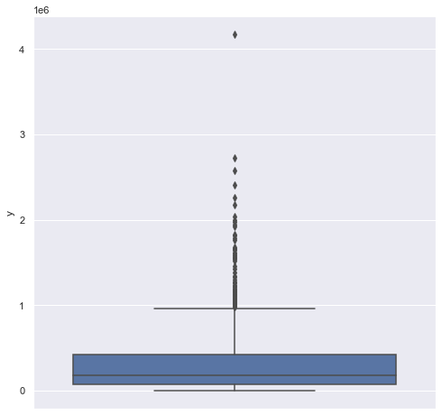

```python
a4_dims = (8, 8)
fig, ax = plt.subplots(figsize=a4_dims)
sns.set(style="dark")
sns.set(style="darkgrid", color_codes=True)
sns.boxplot(y=data.y, color='b')
```

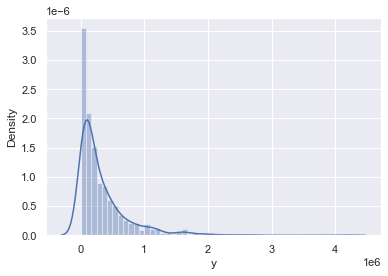

```python
sns.distplot(data['y'],kde=True)
```

# Data Preprocessing

Since I want to build a model only on the basis of numeric variables, I’ll drop out my only categorical variable in the dataset, that is, the “valuationdate” variable.

```python
data_final=data.drop(['valuationdate'],axis=1)
```

Our final data columns will be:

```python
data_final
data_final.columns.values
```

```
array(['revenues', 'ebit', 'depreciation', 'capex', 'ncwc', 'bv', 'y'],
      dtype=object)
```

# Splitting the Dataset into Train and Test Sets

Learning the parameters of a prediction function and testing it on the same data is a methodological mistake: a model that would just repeat the labels of the samples that it has just seen would have a perfect score but would fail to predict anything useful on yet-unseen data.

his situation is called overfitting. To avoid it, it is common practice when performing a (supervised) machine learning experiment to hold out part of the available data as a test set X_test, y_test.

Note that the word “experiment” is not intended to denote academic use only, because even in commercial settings machine learning usually starts out experimentally.

```python
X = data_final.loc[:, data_final.columns != 'y']
y = data_final.loc[:, data_final.columns == 'y']

X_train, X_test, y_train, y_test = train_test_split(X, y, test_size=0.33, random_state=42)

print("length of the total data is ",len(X))
print("length of the train data is ",len(X_train))
print("length of the test data is is ",len(X_test))
```

```
length of the total data is  1061
length of the train data is  710
length of the test data is is  351
```

# Recursive Feature Elimination

Recursive Feature Elimination (RFE) is based on the idea to repeatedly construct a model and choose either the best or worst performing feature, setting the feature aside and then repeating the process with the rest of the features. This process is applied until all features in the dataset are exhausted. The goal of RFE is to select features by recursively considering smaller and smaller sets of features.

```python
data_final_vars=data_final.columns.values.tolist()
y1=["y"]
X1=[i for i in data_final_vars if i not in y1]

from sklearn.feature_selection import RFE
from sklearn.linear_model import LinearRegression

lin = LinearRegression()
rfe = RFE(lin, 6)
rfe = rfe.fit(X_train, y_train.values.ravel())
print(rfe.support_)
print(rfe.ranking_)
```

```
[ True  True  True  True  True  True]
[1 1 1 1 1 1]
```

The RFE has helped us select the following features: “revenues“, “ebit“, “depreciation“, “capex“, “ncwc“, “bv”.

```python
cols=["revenues", "ebit", "depreciation", "capex", "ncwc", "bv"]
X=X_train[cols]
y=y_train["y"]

print("length of the train data is ",len(X))
```

```
length of the train data is  710
```

# Implementing the model

```python
import statsmodels.api as st
X1 = st.add_constant(X)
lin_model=st.OLS(y,X1)
result=lin_model.fit()
print(result.summary2())
```

```
                    Results: Ordinary least squares
=======================================================================
Model:                OLS               Adj. R-squared:      0.672
Dependent Variable:   y                 AIC:                 19495.0240
Date:                 2021-10-07 02:32  BIC:                 19526.9808
No. Observations:     710               Log-Likelihood:      -9740.5
Df Model:             6                 F-statistic:         243.4
Df Residuals:         703               Prob (F-statistic):  7.10e-168
R-squared:            0.675             Scale:               4.8756e+10
-----------------------------------------------------------------------
               Coef.     Std.Err.     t    P>|t|    [0.025     0.975]
-----------------------------------------------------------------------
const        65125.3129 10930.8135  5.9580 0.0000 43664.3636 86586.2623
revenues         0.0833     0.0556  1.4979 0.1346    -0.0259     0.1926
ebit             5.4269     0.5354 10.1361 0.0000     4.3758     6.4781
depreciation     3.5255     1.2021  2.9328 0.0035     1.1654     5.8856
capex           -7.3419     0.8841 -8.3042 0.0000    -9.0778    -5.6061
ncwc             0.2858     0.1875  1.5240 0.1280    -0.0824     0.6540
bv               2.0190     0.1668 12.1064 0.0000     1.6916     2.3465
-----------------------------------------------------------------------
Omnibus:              539.961        Durbin-Watson:           2.073
Prob(Omnibus):        0.000          Jarque-Bera (JB):        15745.247
Skew:                 3.092          Prob(JB):                0.000
Kurtosis:             25.226         Condition No.:           393678
=======================================================================
* The condition number is large (4e+05). This might indicate
strong multicollinearity or other numerical problems.
```

The p-values for most of the variables are smaller than 0.05, except two variables, therefore, we will remove them.

```python
cols=["ebit", "depreciation", "capex", "bv"]
X=X_train[cols]
y=y_train['y']

print("length of the train data is ",len(X))
```

```
length of the train data is  710
```

```python
X1 = st.add_constant(X)
lin_model=st.OLS(y,X1)
result=lin_model.fit()
print(result.summary2())
```

```
                    Results: Ordinary least squares
=======================================================================
Model:                OLS               Adj. R-squared:      0.671
Dependent Variable:   y                 AIC:                 19496.0843
Date:                 2021-10-07 02:32  BIC:                 19518.9106
No. Observations:     710               Log-Likelihood:      -9743.0
Df Model:             4                 F-statistic:         362.3
Df Residuals:         705               Prob (F-statistic):  2.38e-169
R-squared:            0.673             Scale:               4.8965e+10
-----------------------------------------------------------------------
               Coef.     Std.Err.     t    P>|t|    [0.025     0.975]
-----------------------------------------------------------------------
const        69850.4566 10731.3576  6.5090 0.0000 48781.2111 90919.7021
ebit             5.6016     0.5271 10.6279 0.0000     4.5668     6.6364
depreciation     3.3747     1.1967  2.8199 0.0049     1.0251     5.7243
capex           -7.2132     0.8528 -8.4584 0.0000    -8.8875    -5.5389
bv               2.1525     0.1561 13.7860 0.0000     1.8459     2.4590
-----------------------------------------------------------------------
Omnibus:              534.255        Durbin-Watson:           2.093
Prob(Omnibus):        0.000          Jarque-Bera (JB):        15321.301
Skew:                 3.048          Prob(JB):                0.000
Kurtosis:             24.926         Condition No.:           177595
=======================================================================
* The condition number is large (2e+05). This might indicate
strong multicollinearity or other numerical problems.
```

# Linear Regression Model Fitting

```python
from sklearn.linear_model import LinearRegression
from sklearn import metrics
X_train, X_test, y_train, y_test = train_test_split(X, y, test_size=0.33, random_state=42)

print("length of the total data is ",len(X))
print("length of the train data is ",len(X_train))
print("length of the test data is is ",len(X_test))
```

```
length of the total data is  710
length of the train data is  475
length of the test data is is  235
```

```python
lin = LinearRegression()
lin.fit(X_train, y_train)
```

```
LinearRegression()
```

The R2 (a.k.a. R squared or coefficient of determination) is a measure of a regression algorithm’s precision. Best possible score for R2 is 1.0 and it can be negative (because the model can be arbitrarily worse). A constant model that always predicts the expected value of y, disregarding the input features, would get a R2 score of 0.0.

### Predicting the test set results and calculating the precision

```python
y_pred = lin.predict(X_test)
from sklearn.metrics import r2_score
print("Linear Regression R squared of the test set is: {:.2f}".format(r2_score(y_test, y_pred)))
```

```
Linear Regression R squared of the test set is: 0.61
```

So, in our model, 60.75% of the variability in Y can be explained using X. This is not that exciting.

# Compute MSE, RMSE and MAE

The MSE is the mean squared error regression loss. MSE is a measure of a regression algorithm's accuracy. As it is derived from the square of Euclidean distance, it is always a positive value with the error decreasing as the error approaches zero.

```python
from sklearn.metrics import mean_squared_error
print("Linear Regression MSE of the test set is: {:.2f}".format(mean_squared_error(y_test, y_pred)))
```

```
Linear Regression MSE of the test set is: 54901555988.12
```

The RMSE is the root mean squared error regression loss. RMSE is a measure of a regression algorithm's accuracy. As it is derived from the square root of the square of Euclidean distance, it is always a positive value with the error decreasing as the error approaches zero.

```python
lin_rmse = np.sqrt(mean_squared_error(y_pred, y_test))
print("Linear Regression RMSE of the test set is: {:.2f}".format(lin_rmse))
```

```
Linear Regression RMSE of the test set is: 234310.81
```

The MAE is the mean absolute error regression loss. The MAE is a measure of a regression algorithm's accuracy. As it is derived from the Manhattan distance (i.e., the absolute value of Euclidean distance), it is always a positive value with the error decreasing as the error approaches zero.

```python
from sklearn.metrics import mean_absolute_error
print("Linear Regression MAE of the test set is: {:.2f}".format(mean_absolute_error(y_test, y_pred)))
```

```
Linear Regression MAE of the test set is: 130757.81
```

# Comparison predicted and true enterprise value

We can compare the predicted with the true enterprise value. Let us inspect the differences in a DataFrame.

First, we concatenate the true and predicted enterprise value.

```python
d = {'true': y_test, 'predicted': y_pred}
df = pd.DataFrame(data=d)
```

And compute the difference score, which will show us if more values are positive or negative:

```python
df['diff'] = df['predicted']-df['true']
df.head()
```

|  | true | predicted | diff |
| --- | --- | --- | --- |
| 537 | 5.550344e+05 | 525180.051892 | -29854.318508 |
| 57 | 1.635538e+05 | 189687.925095 | 26134.174395 |
| 130 | 3.651706e+05 | 459606.343358 | 94435.750358 |
| 469 | 4.088116e+05 | 493587.710212 | 84776.110212 |
| 896 | 1.112490e+06 | 814061.685355 | -298428.424645 |

```python
print("length of the test data is is ",len(X_test))
print("number of the overestimations for the enterprise value is ",len(df['diff'][df['diff']>0]))
print("number of the underestimations for the enterprise value is ",len(df['diff'][df['diff']<0]))
print("number of the exact estimations for the enterprise value is ",len(df['diff'][df['diff']==0]))
```

```
length of the test data is is  235
number of the overestimations for the enterprise value is  151
number of the underestimations for the enterprise value is  84
number of the exact estimations for the enterprise value is  0
```

There is a tendency of overestimation for the enterprise test values, as we can see in the histogram below:

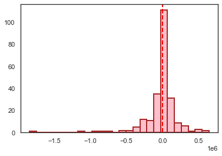

```python
sns.set(style="white")
plt.hist(df['diff'], bins=26, color="pink", edgecolor='brown', linewidth=2)
plt.axvline(0, color="red", linestyle='dashed', linewidth=2)
plt.show()
```

In many data science projects, slight overestimation is not a real problem. This can however be a risky business in the current case.